# US Car Accidents

Chih-Yun

2022-07

## Data Set

- This is a countrywide car accident data set, which covers 49 states of the USA.
- Data collected from February 2016 to Dec 2021(about 2.8 million accident records in this dataset),using multiple APIs that provide streaming traffic incident (or event) data.
- Data scurce: https://www.kaggle.com/datasets/sobhanmoosavi/us-accidents

## Retrieve Dataset

2845342 instances & 47 columns

```r
accident <- read.csv("US_Accidents_Dec21_updated.csv")
cat("Dimension of the data frame : ", dim(accident))
```

```
## Dimension of the data frame :  2845342 47
```

```r
# head(accident, 3)
```

## Dataset Description

### Summary

```r
summary(accident)
```

```
##       ID               Severity      Start_Time          End_Time
##  Length:2845342     Min.   :1.000   Length:2845342     Length:2845342
##  Class :character   1st Qu.:2.000   Class :character   Class :character
##  Mode  :character   Median :2.000   Mode  :character   Mode  :character
##                     Mean   :2.138
##                     3rd Qu.:2.000
##                     Max.   :4.000
##
##    Start_Lat       Start_Lng          End_Lat         End_Lng
##  Min.   :24.57   Min.   :-124.55   Min.   :24.57   Min.   :-124.55
##  1st Qu.:33.45   1st Qu.:-118.03   1st Qu.:33.45   1st Qu.:-118.03
##  Median :36.10   Median : -92.42   Median :36.10   Median : -92.42
##  Mean   :36.25   Mean   : -97.11   Mean   :36.25   Mean   : -97.11
##  3rd Qu.:40.16   3rd Qu.: -80.37   3rd Qu.:40.16   3rd Qu.: -80.37
##  Max.   :49.00   Max.   : -67.11   Max.   :49.08   Max.   : -67.11
##
##   Distance.mi.      Description            Number           Street
##  Min.   :  0.0000   Length:2845342     Min.   :      0   Length:2845342
##  1st Qu.:  0.0520   Class :character   1st Qu.:   1270   Class :character
##  Median :  0.2440   Mode  :character   Median :   4007   Mode  :character
##  Mean   :  0.7027                      Mean   :   8089
##  3rd Qu.:  0.7640                      3rd Qu.:   9567
##  Max.   :155.1860                      Max.   :9999997
##                                        NA's   :1743911
##      Side               City              County             State
##  Length:2845342     Length:2845342     Length:2845342     Length:2845342
##  Class :character   Class :character   Class :character   Class :character
##  Mode  :character   Mode  :character   Mode  :character   Mode  :character
##
##
##
##
##    Zipcode            Country            Timezone         Airport_Code
##  Length:2845342     Length:2845342     Length:2845342     Length:2845342
##  Class :character   Class :character   Class :character   Class :character
##  Mode  :character   Mode  :character   Mode  :character   Mode  :character
##
##
##
##
```

[output cut: 41 more lines]

```
##  Length:2845342     Length:2845342     Length:2845342     Length:2845342
##  Class :character   Class :character   Class :character   Class :character
##  Mode  :character   Mode  :character   Mode  :character   Mode  :character
##
##
##
##
##  Civil_Twilight     Nautical_Twilight  Astronomical_Twilight
##  Length:2845342     Length:2845342     Length:2845342
##  Class :character   Class :character   Class :character
##  Mode  :character   Mode  :character   Mode  :character
##
##
##
##
```

### Data Type

```r
str(accident)
```

```
## 'data.frame':    2845342 obs. of  47 variables:
##  $ ID                   : chr  "A-1" "A-2" "A-3" "A-4" ...
##  $ Severity             : int  3 2 2 2 3 2 2 2 2 2 ...
##  $ Start_Time           : chr  "2016-02-08 00:37:08" "2016-02-08 05:56:20" "2016-02-08 06:15:39" "2016-02-08 06:51:45" ...
##  $ End_Time             : chr  "2016-02-08 06:37:08" "2016-02-08 11:56:20" "2016-02-08 12:15:39" "2016-02-08 12:51:45" ...
##  $ Start_Lat            : num  40.1 39.9 39.1 41.1 39.2 ...
##  $ Start_Lng            : num  -83.1 -84.1 -84.5 -81.5 -84.5 ...
##  $ End_Lat              : num  40.1 39.9 39.1 41.1 39.2 ...
##  $ End_Lng              : num  -83 -84 -84.5 -81.5 -84.5 ...
##  $ Distance.mi.         : num  3.23 0.747 0.055 0.123 0.5 ...
##  $ Description          : chr  "Between Sawmill Rd/Exit 20 and OH-315/Olentangy Riv Rd/Exit 22 - Accident." "At OH-4/OH-235/Exit 41 - Accident." "At I-71/US-50/Exit 1 - Accident." "At Dart Ave/Exit 21 - Accident." ...
##  $ Number               : num  NA NA NA NA NA NA NA NA NA NA ...
##  $ Street               : chr  "Outerbelt E" "I-70 E" "I-75 S" "I-77 N" ...
##  $ Side                 : chr  "R" "R" "R" "R" ...
##  $ City                 : chr  "Dublin" "Dayton" "Cincinnati" "Akron" ...
```

[output cut: 33 more lines]

### Cleaning Data

- Data Pre-processing: Remove unneeded variables
- Sample dimensions now : 2214528 x 27

```r
# drop Lat and Lng, wind chill is the same as temp so drop that
accident[,c('ID','End_Lat', 'End_Lng', "Number", "Description", "Wind_Chill(F)")] <- NULL
accident[,c("Street", "City", "County","State", "Zipcode", "Country", "Airport_Code", "Weather_Timestamp", "Wind_Direction", "Weather_Condition",
            "Crossing","Turning_Loop", "Civil_Twilight", "Nautical_Twilight", "Astronomical_Twilight")] <- NULL

#  ----- drop remaining missing values --------
accident <- accident[complete.cases(accident),]
cat("Reassign or remove missing Values. Total missig values now = ",sum(is.na(accident)))
```

```
## Reassign or remove missing Values. Total missig values now =  0
```

```r
cat("\nSample dimensions now : ", dim(accident))
```

```
##
## Sample dimensions now :  2214528 27
```

```r
# str(accident)
head(accident)
```

```
##    Severity          Start_Time            End_Time Start_Lat Start_Lng
## 1         3 2016-02-08 00:37:08 2016-02-08 06:37:08  40.10891 -83.09286
## 5         3 2016-02-08 07:53:43 2016-02-08 13:53:43  39.17239 -84.49279
## 8         2 2016-02-08 11:51:46 2016-02-08 17:51:46  41.37531 -81.82017
## 10        2 2016-02-08 15:16:43 2016-02-08 21:16:43  40.10931 -82.96849
## 11        2 2016-02-08 15:43:50 2016-02-08 21:43:50  39.19288 -84.47723
## 13        2 2016-02-08 17:27:39 2016-02-08 23:27:39  41.47390 -81.70423
##    Distance.mi. Side   Timezone Temperature.F. Wind_Chill.F. Humidity...
## 1         3.230    R US/Eastern           42.1          36.1          58
## 5         0.500    R US/Eastern           37.0          29.8          93
## 8         0.521    R US/Eastern           33.1          30.0          92
## 10        0.826    R US/Eastern           32.0          28.7         100
## 11        0.307    R US/Eastern           33.8          29.6         100
## 13        0.070    R US/Eastern           33.1          24.4          96
##    Pressure.in. Visibility.mi. Wind_Speed.mph. Precipitation.in. Amenity  Bump
```

[output cut: 20 more lines]

### Statistics

```r
library(pastecs)

options(scipen=100) ## Force R to use the standard notation, not the exponential notation.
options(digits = 2)
stat.desc(accident)
```

```
##                   Severity Start_Time End_Time     Start_Lat      Start_Lng
## nbr.val      2214528.00000         NA       NA  2214528.0000    2214528.000
## nbr.null           0.00000         NA       NA        0.0000          0.000
## nbr.na             0.00000         NA       NA        0.0000          0.000
## min                1.00000         NA       NA       24.5660       -124.548
## max                4.00000         NA       NA       49.0006        -67.484
## range              3.00000         NA       NA       24.4346         57.064
## sum          4595443.00000         NA       NA 79753713.5844 -214000710.065
## median             2.00000         NA       NA       35.7526        -91.080
## mean               2.07513         NA       NA       36.0139        -96.635
## SE.mean            0.00026         NA       NA        0.0037          0.012
## CI.mean.0.95       0.00051         NA       NA        0.0072          0.024
## var                0.14740         NA       NA       29.9381        333.532
## std.dev            0.38392         NA       NA        5.4716         18.263
## coef.var           0.18501         NA       NA        0.1519         -0.189
##              Distance.mi. Side Timezone Temperature.F. Wind_Chill.F.
## nbr.val       2214528.000   NA       NA    2214528.000   2214528.000
## nbr.null       310800.000   NA       NA        832.000      1304.000
## nbr.na              0.000   NA       NA          0.000         0.000
## min                 0.000   NA       NA        -33.000       -50.100
## max               155.186   NA       NA        196.000       196.000
## range             155.186   NA       NA        229.000       246.100
## sum           1545536.064   NA       NA  136941574.700 134455418.700
## median              0.210   NA       NA         64.000        64.000
## mean                0.698   NA       NA         61.838        60.715
## SE.mean             0.001   NA       NA          0.012         0.014
## CI.mean.0.95        0.002   NA       NA          0.024         0.027
## var                 2.285   NA       NA        344.920       421.469
## std.dev             1.512   NA       NA         18.572        20.530
## coef.var            2.166   NA       NA          0.300         0.338
##                Humidity...   Pressure.in. Visibility.mi. Wind_Speed.mph.
## nbr.val        2214528.000  2214528.00000   2214528.0000    2214528.0000
## nbr.null             0.000        0.00000      2972.0000     409610.0000
## nbr.na               0.000        0.00000         0.0000          0.0000
## min                  1.000       16.72000         0.0000          0.0000
## max                100.000       58.90000       100.0000       1087.0000
## range               99.000       42.18000       100.0000       1087.0000
## sum          143217219.000 65045573.53000  20035610.5100   15835461.7000
## median              67.000       29.73000        10.0000          7.0000
## mean                64.672       29.37221         9.0474          7.1507
```

[output cut: 35 more lines]

```
##              Sunrise_Sunset
## nbr.val                  NA
## nbr.null                 NA
## nbr.na                   NA
## min                      NA
## max                      NA
## range                    NA
## sum                      NA
## median                   NA
## mean                     NA
## SE.mean                  NA
## CI.mean.0.95             NA
## var                      NA
## std.dev                  NA
## coef.var                 NA
```

```r
# library(psych)
# describe(accident)
```

## Time Based Variables

```r
library(lubridate)
library(dplyr)
accident$hr <- lubridate::hour(accident$Start_Time)
accident$day <- lubridate::day(accident$Start_Time)
accident$week <- lubridate::week(accident$Start_Time)
accident$month <- lubridate::month(accident$Start_Time)
accident$Weekday <- lubridate::wday(accident$Start_Time, label=T, abbr=F)
accident$year <- lubridate::year(accident$Start_Time)

accident%>%
  select(Severity, Start_Time, hr,day, week, month, Weekday, year)%>%
  head(5)
```

```
##    Severity          Start_Time hr day week month Weekday year
## 1         3 2016-02-08 00:37:08  0   8    6     2  Monday 2016
## 5         3 2016-02-08 07:53:43  7   8    6     2  Monday 2016
## 8         2 2016-02-08 11:51:46 11   8    6     2  Monday 2016
## 10        2 2016-02-08 15:16:43 15   8    6     2  Monday 2016
## 11        2 2016-02-08 15:43:50 15   8    6     2  Monday 2016
```

### Prepare to visualize

```r
# ---- Character to Factor then Numeric
chr_col <- c("Severity","Side","Timezone","Sunrise_Sunset")
accident[, chr_col] <- accident %>%
  select("Severity", "Side","Timezone","Sunrise_Sunset") %>%
  lapply(as.factor)
# --- Boolean to Factor then Numeric  -------
boo_col <- c("Amenity", "Bump", "Give_Way", "Junction",
             "No_Exit", "Railway", "Roundabout", "Station", "Stop",
             "Traffic_Calming", "Traffic_Signal")
accident[, boo_col] <- accident %>%
  select("Amenity", "Bump", "Give_Way", "Junction",
         "No_Exit", "Railway", "Roundabout", "Station", "Stop",
         "Traffic_Calming", "Traffic_Signal") %>%
  lapply(as.factor)

# ---- Factor Recode for Visualizations
library(dplyr)
library(forcats)
accident <- mutate(accident, Traffic_Signal = fct_recode(Traffic_Signal,
                              "No Signal" = "False",
                              "Traffic Signal" = "True"))

accident <- accident %>% mutate(Severity = fct_recode(Severity,
                                   'Low' = '1',
                                   'Medium' = '2',
                                   'High' = '3',
                                   'Severe' = '4'))
table(accident$Severity)
```

```
##
##     Low  Medium    High  Severe
##   23596 2063618   64645   62669
```

### Visualization

##### Which areas of the United States have more of the reported accidents in this data set?

#### US Accidents Occur by Severity (Geom_map)

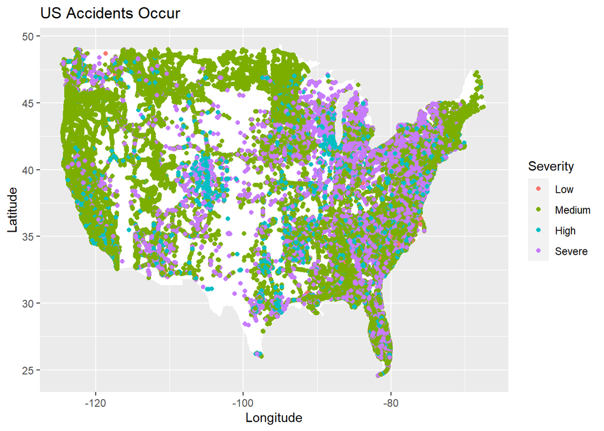

```r
library(maps)
library(ggplot2)
library(tidyverse)
library(RColorBrewer)
pal = brewer.pal(4, "YlGnBu")
states_map <- map_data("state")
map <- ggplot()+
        geom_map(map=states_map, mapping = aes( map_id = states_map$region, x = states_map$long, y = states_map$lat), fill = "white", size = 2.5) +
        geom_point(data = accident, mapping = aes( x = Start_Lng, y = Start_Lat, color = Severity), size = 1.5) +
        labs(x = "Longitude", y = "Latitude", title = "US Accidents Occur")
map
```

#### US Accidents Occur by Timezone (Pie_Chart)

Most of the accidents occurred in the eastern region.

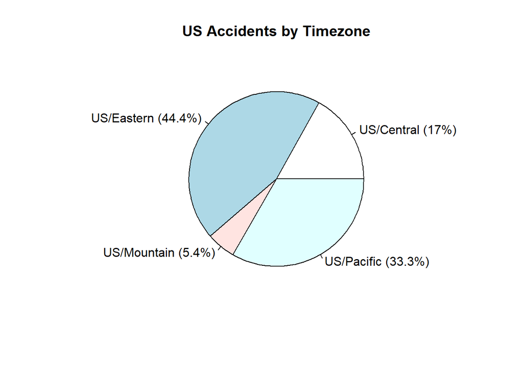

```r
Timezone_R <- table(accident$Timezone)
TimeZone_value <- as.vector(Timezone_R)
TimeZone_label <- names(Timezone_R)
piepercent<- round(100*TimeZone_value/sum(TimeZone_value), 1)
piepercent_label = paste(TimeZone_label," (", piepercent,"%)", sep = "")

pie(TimeZone_value, piepercent_label, main = "US Accidents by Timezone")
```

#### Accidents by Severity

The highest frequency of severity is Medium.

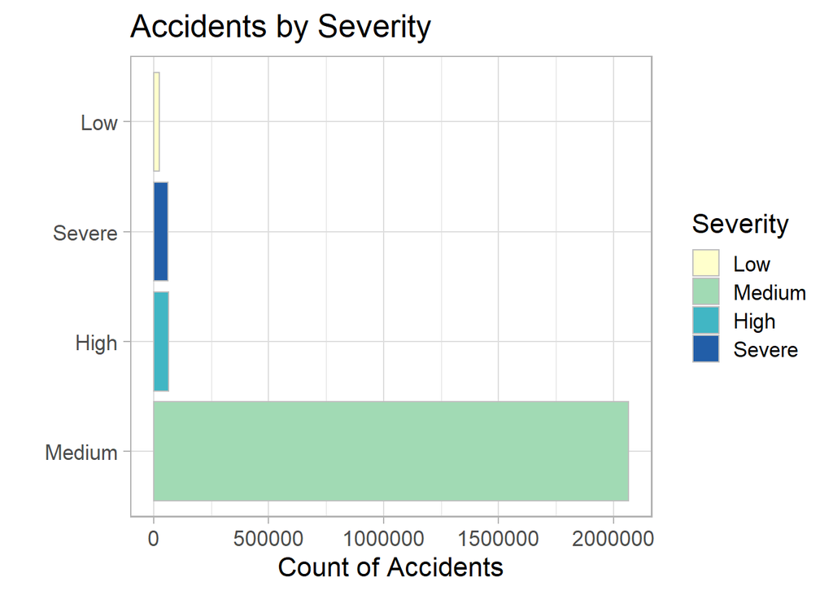

```r
# pal = brewer.pal(4, "YlGnBu")
# options(repr.plot.width=10, repr.plot.height=8)
ggplot(accident, aes(x = fct_infreq(Severity), fill = Severity)) + geom_bar(stat = "count", color = "gray") +
  labs(x = "", y = "Count of Accidents", title = "Accidents by Severity") +
  coord_flip()+
  scale_fill_manual(values=pal) + theme_light(base_size = 16)
```

#### Accidents by Traffic Signal & Severity

Especially when there is no traffic signal!

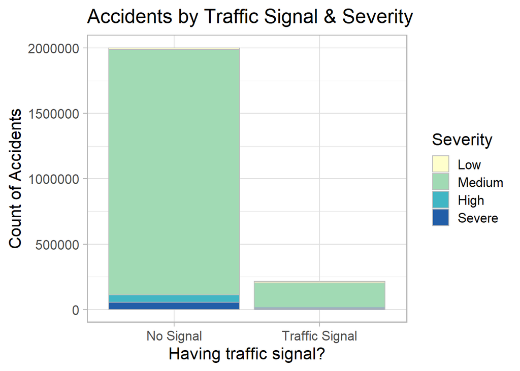

```r
#--- Severity by accident count & traffic signal  -----
ggplot(accident, aes(x = fct_infreq(Traffic_Signal), fill = Severity)) +
  theme_bw()+
  geom_bar(stat = "count", color="grey") + theme_light(base_size = 16)+
  labs(x="Having traffic signal?",y = "Count of Accidents", title = "Accidents by Traffic Signal & Severity") +
  scale_fill_manual(values=pal)
```

#### Display the time of accidents

##### Accidents by Day & Hour & Severity

Most accidents happened in the weekday around 16:00~17:00, it might because of the commuting time.

```r
h <- accident %>% group_by(hr, Weekday, Severity)%>%
                  summarise(n = n())
```

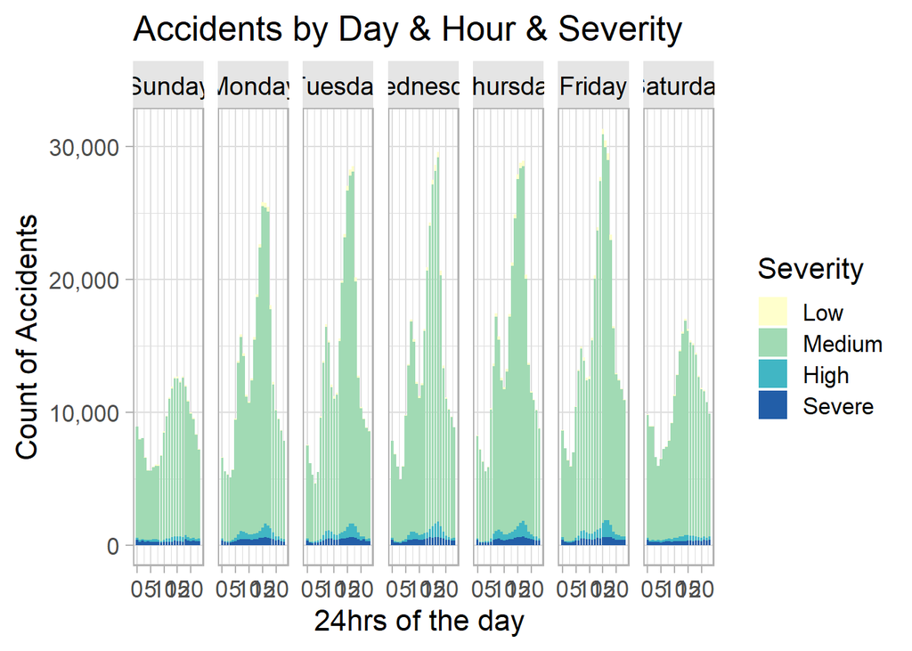

```r
# ---- by hour, Weekday & Severity  --------
# options(repr.plot.width=40, repr.plot.height=20)
pal = brewer.pal(4, "YlGnBu")
ggplot(h,aes(hr,n, fill = Severity)) + geom_bar(stat = "identity") +
  facet_grid(~Weekday) +
  labs(x = "24hrs of the day ", y = "Count of Accidents", title = "Accidents by Day & Hour & Severity") +
  theme_light(base_size = 16) +
  scale_fill_manual(values = pal) +
  theme(strip.background = element_rect(fill="grey90")) +
  theme(strip.text = element_text(size = 14, color = 'black')) +
  scale_y_continuous(labels = scales::comma)
```

#### US Car Accidents by Year

2020 & 2021 have most accidents might because of the COVID.

```r
y <- accident %>% group_by(year, Severity)%>%
                  summarise(n = n())
```

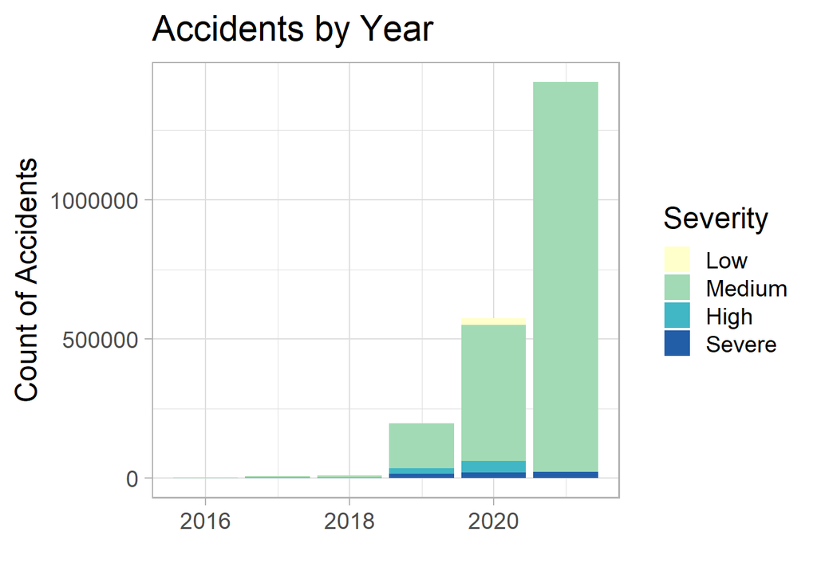

```r
pal = brewer.pal(4, "YlGnBu")
ggplot(y, aes(year, n, fill = Severity)) + geom_bar(stat = "identity") +
  labs(x = "", y = "Count of Accidents",title = "Accidents by Year") +
  scale_fill_manual(values = pal) +
  theme_light(base_size = 18)
```

### Data Cleaning for Model

- Remove unneeded variables
- Define NA values

#### Remove unneeded variables

```r
#Already Drop Above
# accident[,c('ID','End_Lat', 'End_Lng', "Number", "Description", "Wind_Chill(F)")] <- NULL
# accident[,c("Street", "City", "County","State", "Zipcode", "Country", "Airport_Code", "Weather_Timestamp", "Wind_Direction", "Weather_Condition",
#             "Crossing","Turning_Loop", "Civil_Twilight", "Nautical_Twilight", "Astronomical_Twilight")] <- NULL
accident[,c("hr", "day", "week","month", "Weekday", "year", "Start_Time", "End_Time")] <- NULL
# head(accident)
```

#### Define NA values

```r
library(zoo)
accident$Severity[is.na(accident$Severity)] = "NAN"
accident$Distance.mi.[is.na(accident$Distance.mi.)] = 0
accident$Side[is.na(accident$Side)] = "Neither"
accident$Temperature.F.[is.na(accident$Temperature.F.)] = na.approx(accident$Temperature.F., rule = 2)
accident$Humidity...[is.na(accident$Humidity...)] = 0
accident$Pressure.in.[is.na(accident$Pressure.in.)] = na.approx(accident$Pressure.in., rule = 2)
accident$Visibility.mi.[is.na(accident$Visibility.mi.)] = 0
accident$Wind_Speed.mph.[is.na(accident$Wind_Speed.mph.)] = 0
accident$Precipitation.in.[is.na(accident$Precipitation.in.)] = 0
accident$Sunrise_Sunset[is.na(accident$Sunrise_Sunset)] = "Unknown"
# summary(accident)
```

### Create data partition for Models

This chunk creates a data partition to be used for a random forest model. This model will help determine which variables have most impact on the severity factor assigned to the accident. The data is shortened to 25000 observations with random sampling so the code will be able to run.

- Training data (80%)
- Testing data (20%)

```r
accident$Severity <- as.factor(accident$Severity)
sampled_accident <- accident[sample(nrow(accident), size = 25000), ]

set.seed(12345)
library(caret)
trainingInd <- createDataPartition(sampled_accident$Severity, p = 0.8, list = FALSE)

training <- sampled_accident[trainingInd, ]
testing <- sampled_accident[-trainingInd, ]

str(training)
```

```
## 'data.frame':    20002 obs. of  25 variables:
##  $ Severity         : Factor w/ 4 levels "Low","Medium",..: 2 2 2 2 2 2 2 2 4 2 ...
##  $ Start_Lat        : num  37.8 30.2 32.7 28.9 40.9 ...
##  $ Start_Lng        : num  -121.2 -85.6 -117.2 -82.1 -74.1 ...
##  $ Distance.mi.     : num  0 0.026 1.153 2.998 0.558 ...
##  $ Side             : Factor w/ 2 levels "L","R": 2 2 2 2 2 2 1 2 1 2 ...
##  $ Timezone         : Factor w/ 4 levels "US/Central","US/Eastern",..: 4 1 4 2 2 1 4 2 3 2 ...
##  $ Temperature.F.   : num  64 75 54 83 36 63 45 86 94 71 ...
##  $ Wind_Chill.F.    : num  64 75 54 83 29 63 39 86 94 71 ...
##  $ Humidity...      : num  40 78 83 41 62 94 74 58 35 84 ...
##  $ Pressure.in.     : num  29.9 30 30.1 29.9 30 ...
##  $ Visibility.mi.   : num  10 10 10 10 10 10 10 10 10 5 ...
##  $ Wind_Speed.mph.  : num  10 18 0 0 9 0 12 6 3 3 ...
##  $ Precipitation.in.: num  0 0 0 0 0 0 0 0 0 0 ...
##  $ Amenity          : Factor w/ 2 levels "False","True": 1 1 1 1 1 1 1 1 1 1 ...
##  $ Bump             : Factor w/ 2 levels "False","True": 1 1 1 1 1 1 1 1 1 1 ...
##  $ Give_Way         : Factor w/ 2 levels "False","True": 1 1 1 1 1 1 1 1 1 1 ...
##  $ Junction         : Factor w/ 2 levels "False","True": 1 1 2 1 1 1 1 1 1 1 ...
##  $ No_Exit          : Factor w/ 2 levels "False","True": 1 1 1 1 1 1 1 1 1 1 ...
##  $ Railway          : Factor w/ 2 levels "False","True": 1 1 1 1 1 1 1 1 1 1 ...
##  $ Roundabout       : Factor w/ 2 levels "False","True": 1 1 1 1 1 1 1 1 1 1 ...
##  $ Station          : Factor w/ 2 levels "False","True": 1 1 1 1 1 1 1 1 1 1 ...
##  $ Stop             : Factor w/ 2 levels "False","True": 1 1 1 1 1 1 1 1 1 1 ...
##  $ Traffic_Calming  : Factor w/ 2 levels "False","True": 1 1 1 1 1 1 1 1 1 1 ...
##  $ Traffic_Signal   : Factor w/ 2 levels "No Signal","Traffic Signal": 1 1 1 1 1 1 1 1 1 1 ...
##  $ Sunrise_Sunset   : Factor w/ 3 levels "","Day","Night": 2 2 2 2 2 3 2 2 2 3 ...
```

```r
str(testing)
```

```
## 'data.frame':    4998 obs. of  25 variables:
##  $ Severity         : Factor w/ 4 levels "Low","Medium",..: 2 2 2 2 2 2 2 2 2 2 ...
##  $ Start_Lat        : num  38.6 39.9 38.7 35.1 34 ...
##  $ Start_Lng        : num  -77.3 -75.1 -77.2 -89.9 -118.2 ...
##  $ Distance.mi.     : num  1.67 0.193 0.031 0 0.455 ...
##  $ Side             : Factor w/ 2 levels "L","R": 2 2 2 2 2 2 2 1 2 2 ...
##  $ Timezone         : Factor w/ 4 levels "US/Central","US/Eastern",..: 2 2 2 1 4 2 2 1 2 4 ...
##  $ Temperature.F.   : num  68 85 78 72 50 49 87 14 66 66 ...
##  $ Wind_Chill.F.    : num  68 85 78 72 50 45 87 6 66 66 ...
##  $ Humidity...      : num  97 46 31 94 80 97 61 73 94 47 ...
##  $ Pressure.in.     : num  29.9 29.8 30.4 29.5 30 ...
##  $ Visibility.mi.   : num  6 1 10 10 10 2 10 2 3 10 ...
##  $ Wind_Speed.mph.  : num  0 29 6 16 0 9 14 5 14 0 ...
##  $ Precipitation.in.: num  0 0 0 0 0 0 0 0 0 0 ...
##  $ Amenity          : Factor w/ 2 levels "False","True": 1 1 1 1 1 1 1 1 1 1 ...
##  $ Bump             : Factor w/ 2 levels "False","True": 1 1 1 1 1 1 1 1 1 1 ...
##  $ Give_Way         : Factor w/ 2 levels "False","True": 1 1 1 1 1 1 1 1 1 1 ...
##  $ Junction         : Factor w/ 2 levels "False","True": 1 1 1 1 2 1 1 1 1 1 ...
##  $ No_Exit          : Factor w/ 2 levels "False","True": 1 1 1 1 1 1 1 1 1 1 ...
##  $ Railway          : Factor w/ 2 levels "False","True": 1 1 1 1 1 1 1 1 1 1 ...
##  $ Roundabout       : Factor w/ 2 levels "False","True": 1 1 1 1 1 1 1 1 1 1 ...
##  $ Station          : Factor w/ 2 levels "False","True": 1 1 1 1 1 1 1 1 1 1 ...
##  $ Stop             : Factor w/ 2 levels "False","True": 1 1 1 1 1 1 1 1 1 1 ...
##  $ Traffic_Calming  : Factor w/ 2 levels "False","True": 1 1 1 1 1 1 1 1 1 1 ...
##  $ Traffic_Signal   : Factor w/ 2 levels "No Signal","Traffic Signal": 1 1 1 1 1 1 1 1 2 1 ...
##  $ Sunrise_Sunset   : Factor w/ 3 levels "","Day","Night": 3 2 2 2 3 3 2 2 2 3 ...
```

### Run Random Forest model for severity

We see that the accuracy of the model is ~94% and the kappa is not ideal. So this is not a good model for this data set. But it mentions which variables are most important in predicting severity.

```r
RF <- train(Severity~., data = training,
            method="rf",
            trControl=trainControl(method="CV", 5),
            preProcess=c("center", "scale"))

predicted <- predict(RF, newdata = testing)
confusionMatrix(predicted, testing$Severity)
```

```
## Confusion Matrix and Statistics
##
##           Reference
## Prediction  Low Medium High Severe
##     Low      15      3    4      0
##     Medium   35   4640  103    138
##     High      3      8   36      4
##     Severe    0      8    0      1
##
## Overall Statistics
##
##                Accuracy : 0.939
##                  95% CI : (0.932, 0.945)
##     No Information Rate : 0.932
##     P-Value [Acc > NIR] : 0.0323
##
##                   Kappa : 0.26
##
##  Mcnemar's Test P-Value : NA
##
## Statistics by Class:
##
##                      Class: Low Class: Medium Class: High Class: Severe
## Sensitivity              0.2830         0.996      0.2517       0.00699
## Specificity              0.9986         0.186      0.9969       0.99835
## Pos Pred Value           0.6818         0.944      0.7059       0.11111
## Neg Pred Value           0.9924         0.768      0.9784       0.97154
## Prevalence               0.0106         0.932      0.0286       0.02861
## Detection Rate           0.0030         0.928      0.0072       0.00020
## Detection Prevalence     0.0044         0.984      0.0102       0.00180
## Balanced Accuracy        0.6408         0.591      0.6243       0.50267
```

```r
options(scipen=100)
options(digits = 2)
varImp(RF$finalModel)
```

```
##                              Overall
## Start_Lat                    400.406
## Start_Lng                    487.957
## Distance.mi.                 337.387
## SideR                         27.483
## TimezoneUS/Eastern            25.319
## TimezoneUS/Mountain           17.089
## TimezoneUS/Pacific            32.189
## Temperature.F.               174.004
## Wind_Chill.F.                174.073
## Humidity...                  218.232
## Pressure.in.                 302.947
## Visibility.mi.                58.141
## Wind_Speed.mph.              159.257
## Precipitation.in.             36.764
## AmenityTrue                    7.678
## BumpTrue                       1.110
## Give_WayTrue                   5.169
## JunctionTrue                  21.624
## No_ExitTrue                    0.081
## RailwayTrue                    4.482
## RoundaboutTrue                 1.492
## StationTrue                    9.977
## StopTrue                       6.241
## Traffic_CalmingTrue            2.313
## Traffic_SignalTraffic Signal  37.551
## Sunrise_SunsetDay             23.212
## Sunrise_SunsetNight           23.674
```

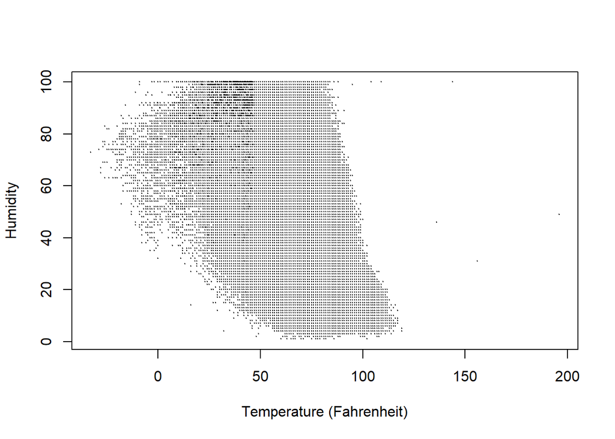

```r
plot(accident$Temperature.F., accident$Humidity..., cex = 0.1, xlab = "Temperature (Fahrenheit)", ylab = "Humidity")
```

```r
cor(accident$Temperature.F., accident$Humidity...)
```

```
## [1] -0.37
```

### Linear Regression model1: With more important variables

(Severity~ Pressure+Humidity+Temperature+Wind Speed)

```r
accident$Severity <- as.numeric(accident$Severity)
LinearModel <- lm(as.numeric(Severity)~Pressure.in.+Humidity...+Temperature.F.+Wind_Speed.mph.,
            data = training)
summary(LinearModel)
```

```
##
## Call:
## lm(formula = as.numeric(Severity) ~ Pressure.in. + Humidity... +
##     Temperature.F. + Wind_Speed.mph., data = training)
##
## Residuals:
##     Min      1Q  Median      3Q     Max
## -1.2056 -0.0847 -0.0696 -0.0565  1.9750
##
## Coefficients:
##                  Estimate Std. Error t value             Pr(>|t|)
## (Intercept)      2.592023   0.073876   35.09 < 0.0000000000000002 ***
## Pressure.in.    -0.017904   0.002612   -6.85      0.0000000000074 ***
## Humidity...      0.000506   0.000134    3.77              0.00017 ***
## Temperature.F.  -0.000467   0.000162   -2.89              0.00385 **
## Wind_Speed.mph.  0.000774   0.000351    2.21              0.02741 *
## ---
## Signif. codes:  0 '***' 0.001 '**' 0.01 '*' 0.05 '.' 0.1 ' ' 1
##
## Residual standard error: 0.38 on 19997 degrees of freedom
## Multiple R-squared:  0.00455,    Adjusted R-squared:  0.00435
## F-statistic: 22.8 on 4 and 19997 DF,  p-value: <0.0000000000000002
```

```r
exp(coef(LinearModel))
```

```
##     (Intercept)    Pressure.in.     Humidity...  Temperature.F. Wind_Speed.mph.
##           13.36            0.98            1.00            1.00            1.00
```

```r
##Predict
# sliced_testing <- testing[c("Pressure.in.", "Humidity...", "Temperature.F.", "Wind_Speed.mph.")]
# predicted_L <- predict(LinearModel, sliced_testing)
```

### Linear Regression model2: With more important variables

(Severity~ Distance)

```r
LinearModel2 <- lm(as.numeric(Severity)~Distance.mi., data = training)


summary(LinearModel2)
```

```
##
## Call:
## lm(formula = as.numeric(Severity) ~ Distance.mi., data = training)
##
## Residuals:
##     Min      1Q  Median      3Q     Max
## -1.2998 -0.0768 -0.0653 -0.0623  1.9384
##
## Coefficients:
##              Estimate Std. Error t value            Pr(>|t|)
## (Intercept)   2.06164    0.00299   690.1 <0.0000000000000002 ***
## Distance.mi.  0.02010    0.00180    11.2 <0.0000000000000002 ***
## ---
## Signif. codes:  0 '***' 0.001 '**' 0.01 '*' 0.05 '.' 0.1 ' ' 1
##
## Residual standard error: 0.38 on 20000 degrees of freedom
## Multiple R-squared:  0.00621,    Adjusted R-squared:  0.00616
## F-statistic:  125 on 1 and 20000 DF,  p-value: <0.0000000000000002
```

```r
exp(coef(LinearModel2))
```

```
##  (Intercept) Distance.mi.
##          7.9          1.0
```

### Conclusion

- Most car accidents happened in the Eastern United State. (More population there)
- Most car accidents happened when there is no traffic signal.
- Most car accidents happened in the weekday commuting period.
- There are more accidents since 2020, it might due to pandemic and the decrease commuting frequency of public transportation.
- We would need more information to find out what particular factors of car accidents are associated with traffic interference.